# data_loader_playground

## Data Loader Playground

The goal of this file is to play around with the data loader and its configurations.

The ideal loader will create a simulated stream that mimics real-world conditions. This includes inducing controlled nonstationarity in the simulated stream. The nonstationarity tests our learning algorithm on its ability to adapt to varying degrees of concept drift.

### Theory-First Approach

This notebook demonstrates both the legacy `get_synthetic_linear_stream()` and the new theory-first `get_theory_stream()` function. The theory-first approach allows you to specify theoretical constants directly (gradient bounds, path length, strong convexity, etc.) rather than implementation details, enabling experiments parameterized by theoretical properties.

```python
from data_loader import get_synthetic_linear_stream, get_theory_stream

# Legacy linear stream
data_stream = get_synthetic_linear_stream()

# New theory-first stream with theoretical drift configurations
theory_stream = get_theory_stream(
    dim=20, T=10000,
    target_G=5.0, target_D=4.0, target_c=1e-3, target_C=1e3,
    target_lambda=1e-2, target_PT=250.0, target_ST=2.0e6,
    accountant='zcdp', rho_total=1.0, path_style='rotating', seed=42
)
```

### Theory-First Synthetic Stream: `get_theory_stream()`

The new `get_theory_stream()` function provides a theory-driven approach where **theoretical constants are primary inputs** rather than implementation details. This enables experiments parameterized directly by theoretical properties.

#### Key Theory Parameters

- `target_G`: Gradient norm bound to enforce
- `target_D`: Parameter domain diameter
- `target_c`, `target_C`: Inverse-Hessian eigenvalue bounds (for LBFGS conditioning)
- `target_lambda`: Strong convexity parameter
- `target_PT`: Total path length over horizon T
- `target_ST`: Cumulative squared gradient norms (AdaGrad energy)
- `accountant`: Privacy accounting method (`"zcdp"` or `"eps-delta"`)
- `rho_total`/`eps_total`: Privacy budget
- `path_style`: Parameter drift style (`"rotating"`, `"brownian"`, `"piecewise-constant"`)

#### Example Theory-First Usage

```
theory_stream = get_theory_stream(
    dim=20, T=10000,
    target_G=5.0,           # gradient norm bound
    target_D=4.0,           # parameter domain diameter
    target_c=1e-3,          # min inverse-Hessian eigenvalue
    target_C=1e3,           # max inverse-Hessian eigenvalue
    target_lambda=1e-2,     # strong convexity parameter
    target_PT=250.0,        # total path length over horizon
    target_ST=2.0e6,        # cumulative squared gradients
    accountant='zcdp',      # privacy accounting method
    rho_total=1.0,          # total zCDP budget
    path_style='rotating',  # parameter path type
    seed=42
)
```

The function enforces these theoretical constraints through controllers and provides rich diagnostics including constraint adherence metrics.

```python
# Demonstrate theory-first stream with theoretical drift configurations
from data_loader import get_theory_stream
import numpy as np

# Create theory stream with controlled theoretical properties
theory_stream = get_theory_stream(
    dim=10,
    T=5000,
    target_G=2.0,           # gradient norm bound
    target_D=3.0,           # parameter domain diameter
    target_c=0.01,          # min inverse-Hessian eigenvalue
    target_C=100.0,         # max inverse-Hessian eigenvalue
    target_lambda=0.05,     # strong convexity parameter
    target_PT=50.0,         # total path length over horizon
    target_ST=10000.0,      # cumulative squared gradients
    accountant='zcdp',      # privacy accounting method
    rho_total=2.0,          # total zCDP budget
    path_style='rotating',  # parameter path type
    seed=42
)

# Take first few events to examine structure
events = []
for i in range(10):
    event = next(theory_stream)
    events.append(event)

print("Theory stream event structure:")
print("Event keys:", list(events[0].keys()))
print("Metrics keys:", list(events[0]['metrics'].keys()))
print("\nFirst event x shape:", events[0]['x'].shape)
print("First event y:", events[0]['y'])
print("\nTheory targets in metrics:")
print(events[0]['metrics']['theory_targets'])
```

```
Theory stream event structure:
Event keys: ['x', 'y', 'sample_id', 'event_id', 'segment_id', 'metrics']
Metrics keys: ['delta_P', 'x_norm', 'w_star_norm', 'noise', 'theory_targets', 'G_hat', 'D_hat', 'c_hat', 'C_hat', 'P_T_true', 'g_norm', 'clip_applied', 'ST_running', 'PT_target_residual', 'ST_target_residual', 'sigma_step', 'privacy_spend_running']

First event x shape: (10,)
First event y: -0.29701718612338546

Theory targets in metrics:
{'target_G': 2.0, 'target_D': 3.0, 'target_c': 0.01, 'target_C': 100.0, 'target_lambda': 0.05, 'target_PT': 50.0, 'target_ST': 10000.0, 'accountant': 'zcdp', 'rho_total': 2.0, 'eps_total': None, 'delta_total': None}
```

### Legacy Synthetic Linear Stream: `get_synthetic_linear_stream()`

This section demonstrates the legacy `get_synthetic_linear_stream()` function for comparison. **For new experiments, prefer the theory-first `get_theory_stream()` approach above.**

The legacy function exposes implementation details rather than theoretical constants, making it harder to parameterize experiments by theoretical properties.

#### Legacy Function: `get_synthetic_linear_stream()`

Produces an infinite iterator that yields event records with the unified schema:

- `x`: feature vector (`np.ndarray`)
- `y`: target (`float`)
- `sample_id`: stable id
- `event_id`: increasing int
- `segment_id`: int (0 by default)
- `metrics`: dictionary with diagnostics (e.g., `x_norm`, `delta_P`, `w_star_norm`, `noise`, `lambda_est`, `P_T_true`)

#### Parameters and Effects

- `dim`: Feature dimensionality. Larger `dim` changes geometry; affects norms and regression target variability.
- `seed`: RNG seed for reproducibility. Impacts parameter path init, covariance, and noise draws.
- `noise_std`: Standard deviation of additive Gaussian noise in `y`. Larger values increase target variance and reduce signal-to-noise ratio.
- `use_event_schema`: When `True` (recommended), yields event dicts with diagnostics; when `False`, returns a legacy `(x, y)` stream without extra metrics.

Covariance and feature scaling:

- `eigs`: Explicit eigenvalues of the Gaussian feature covariance $\Sigma$. Controls anisotropy; larger spread concentrates variance along top PCs.
- `cond_number`: If `eigs` is not provided, generates geometrically spaced eigenvalues with condition number `cond_number` (Σ spectrum from 1 to 1/cond_number).
- `rand_orth_seed`: Seed for the random orthogonal matrix defining eigenvectors of Σ.
- `feature_scale`: Post-covariance scalar applied to all features. Scales norms and effective step sizes for learners.

Ground-truth parameter path (concept drift):

- `path_type`: One of `"static"`, `"rotating"`, or `"drift"`.
  - `static`: Fixed parameter; no drift (`delta_P = 0`, `P_T_true` flat).
  - `rotating`: Applies a small rotation per step in a 2D subspace; smooth cyclic drift.
  - `drift`: Adds small random drift per step; stochastic wandering.
- `path_control`: Enable/disable controlled path machinery. If `False`, parameters are resampled i.i.d.; drift metrics become trivial.
- `rotate_angle`: Radians per step for `rotating`. Larger angle increases instantaneous drift (`delta_P`) and cumulative path length (`P_T_true`).
- `drift_rate`: Standard deviation of per-step drift for `drift`. Larger values yield more volatile and faster-growing `P_T_true`.
- `w_scale`: If provided and `fix_w_norm=True`, initializes and maintains ‖w*‖ at this value. Useful to isolate orientation drift from norm changes.
- `fix_w_norm`: When `True`, renormalizes the drifting parameter to `w_scale` (or initial norm) each step; when `False`, the norm may grow/shrink.

Diagnostics and estimation:

- `strong_convexity_estimation`: When `True`, includes an online estimate `lambda_est` via a secant-style update using a simple learner surrogate. Expect noisy early estimates that stabilize with time.

#### Key Metrics in `metrics`

- `delta_P`: Per-step path increment ‖w*_t − w*_{t−1}‖ (0 if static).
- `P_T_true`: Cumulative path length up to time t.
- `x_norm`: ‖x‖; influenced by Σ spectrum and `feature_scale`.
- `w_star_norm`: ‖w*‖; constant if `fix_w_norm=True`.
- `noise`: The scalar noise draw added to `x·w*` to produce `y`.
- `lambda_est`: Online strong convexity estimate (if enabled).

Below, we run controlled experiments to visualize how these parameters affect the stream.

#### Comparison: Legacy vs Theory-First Approaches

The key difference is that the theory-first approach lets you specify **what you want** (theoretical properties) rather than **how to achieve it** (implementation details).

```python
# Compare legacy vs theory-first approach for similar drift scenarios

# Theory-first: Specify desired theoretical properties directly
theory_stream = get_theory_stream(
    dim=10, T=1000,
    target_G=1.5,           # Want gradient norms bounded by 1.5
    target_D=2.0,           # Want parameter domain diameter of 2.0
    target_lambda=0.1,      # Want strong convexity of 0.1
    target_PT=20.0,         # Want total path length of 20 over horizon
    target_ST=1000.0,       # Want cumulative squared gradients of 1000
    target_c=0.01, target_C=10.0,  # Condition number control
    accountant='zcdp', rho_total=1.0,
    path_style='rotating', seed=42
)

# Legacy: Specify implementation details and hope for good theoretical properties
legacy_stream = get_synthetic_linear_stream(
    dim=10, seed=42,
    path_type='rotating',
    rotate_angle=0.02,      # Implementation detail: how much to rotate
    cond_number=100.0,      # Implementation detail: eigenvalue spread
    feature_scale=1.0,      # Implementation detail: feature scaling
    w_scale=1.0,            # Implementation detail: parameter scale
    fix_w_norm=True
)

# Collect some events from each to compare
theory_events = [next(theory_stream) for _ in range(5)]
legacy_events = [next(legacy_stream) for _ in range(5)]

print("Theory-first metrics available:")
theory_metrics = set(theory_events[0]['metrics'].keys())
print(sorted(theory_metrics))

print("\nLegacy metrics available:")
legacy_metrics = set(legacy_events[0]['metrics'].keys())
print(sorted(legacy_metrics))

print("\nNew metrics in theory-first:")
print(sorted(theory_metrics - legacy_metrics))

print("\nExample theory targets from theory-first stream:")
if 'theory_targets' in theory_events[0]['metrics']:
    print(theory_events[0]['metrics']['theory_targets'])
```

```
Theory-first metrics available:
['C_hat', 'D_hat', 'G_hat', 'PT_target_residual', 'P_T_true', 'ST_running', 'ST_target_residual', 'c_hat', 'clip_applied', 'delta_P', 'g_norm', 'noise', 'privacy_spend_running', 'sigma_step', 'theory_targets', 'w_star_norm', 'x_norm']

Legacy metrics available:
['C_hat', 'D_hat', 'G_hat', 'P_T_true', 'c_hat', 'delta_P', 'drift_rate', 'noise', 'rotate_angle', 'w_star_norm', 'x_norm']

New metrics in theory-first:
['PT_target_residual', 'ST_running', 'ST_target_residual', 'clip_applied', 'g_norm', 'privacy_spend_running', 'sigma_step', 'theory_targets']

Example theory targets from theory-first stream:
{'target_G': 1.5, 'target_D': 2.0, 'target_c': 0.01, 'target_C': 10.0, 'target_lambda': 0.1, 'target_PT': 20.0, 'target_ST': 1000.0, 'accountant': 'zcdp', 'rho_total': 1.0, 'eps_total': None, 'delta_total': None}
```

## Theoretical Drift Configurations

The theory-first approach excels at creating streams with specific drift characteristics parameterized by theoretical constants.

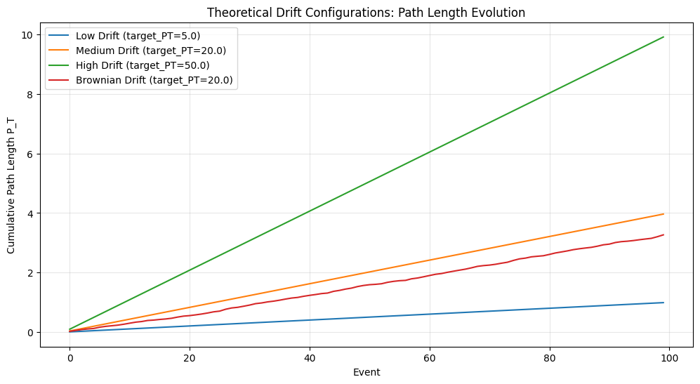

```
The theory-first approach allows direct control over drift characteristics
by specifying target_PT (total path length) rather than implementation details.
```

```python
# Demonstrate different theoretical drift configurations
import matplotlib.pyplot as plt

def analyze_drift_configuration(name, **kwargs):
    """Analyze a drift configuration and return path length progression."""
    stream = get_theory_stream(
        dim=5, T=500, seed=42,
        target_G=2.0, target_D=3.0, target_c=0.01, target_C=100.0,
        target_lambda=0.1, target_ST=500.0,
        accountant='zcdp', rho_total=1.0,
        **kwargs
    )

    path_lengths = []
    for i in range(100):  # Sample first 100 events
        event = next(stream)
        path_lengths.append(event['metrics']['P_T_true'])

    return path_lengths

# Test different drift configurations
configurations = {
    'Low Drift': {'target_PT': 5.0, 'path_style': 'rotating'},
    'Medium Drift': {'target_PT': 20.0, 'path_style': 'rotating'},
    'High Drift': {'target_PT': 50.0, 'path_style': 'rotating'},
    'Brownian Drift': {'target_PT': 20.0, 'path_style': 'brownian'},
}

plt.figure(figsize=(12, 6))
for name, config in configurations.items():
    path_lengths = analyze_drift_configuration(name, **config)
    plt.plot(path_lengths, label=f"{name} (target_PT={config['target_PT']})")

plt.xlabel('Event')
plt.ylabel('Cumulative Path Length P_T')
plt.title('Theoretical Drift Configurations: Path Length Evolution')
plt.legend()
plt.grid(True, alpha=0.3)
plt.show()

print("The theory-first approach allows direct control over drift characteristics")
print("by specifying target_PT (total path length) rather than implementation details.")
```

```python
# Setup and Imports
import sys, os
from pathlib import Path

# Ensure repo root on sys.path so our 'code' package resolves before stdlib 'code'
def add_repo_root_to_path():
    candidates = [
        Path.cwd(),
        Path.cwd().parent,
        *list(Path.cwd().parents)
    ]
    for cand in candidates:
        if (cand / "code" / "__init__.py").exists():
            sys.path.insert(0, str(cand))
            return cand
    return Path.cwd()

proj_root = add_repo_root_to_path()
print("Using project root:", proj_root)

# Ensure plotting/data packages are available
def ensure_packages(pkgs):
    import importlib
    missing = []
    for name, pip_name in pkgs:
        try:
            importlib.import_module(name)
        except ImportError:
            missing.append(pip_name)
    if missing:
        import subprocess
        python = sys.executable
        print("Installing missing packages:", missing)
        subprocess.check_call([python, "-m", "pip", "install", *missing])

ensure_packages([
    ("pandas", "pandas"),
    ("matplotlib", "matplotlib"),
    ("seaborn", "seaborn"),
])

import numpy as np
import pandas as pd
import matplotlib.pyplot as plt
import seaborn as sns

# Inline plots
%matplotlib inline
sns.set_context("talk")
sns.set_style("whitegrid")

# Import the synthetic stream generators (both legacy and theory-first)
from data_loader.linear import get_synthetic_linear_stream
from data_loader.theory_loader import get_theory_stream
from data_loader.event_schema import parse_event_record

print("Imports OK.")
```

```
Using project root: /workspaces/unlearning-research-meta
Imports OK.
```

```python
# print first 10 rows
N = 3
stream = get_synthetic_linear_stream(
    dim=20,
    seed=7,
    noise_std=0.1,
    use_event_schema=True,
    cond_number=50.0,
    feature_scale=1.0,
    path_type="rotating",
    path_control=True,
    rotate_angle=0.01,
    w_scale=2.0,
    fix_w_norm=True,
    strong_convexity_estimation=True,
)
out = []
for _ in range(N):
    out.append(next(stream))

out
```

```
[{'x': array([-0.08765424,  0.05374001,  0.32475385, -0.36460873,  0.14443031,
         -0.13222007, -0.24944358,  0.466017  , -1.0429566 ,  0.15795064,
         -0.6152622 , -0.7019513 ,  0.38832435,  0.20867322,  0.02915494,
          0.43133116,  0.6731134 ,  0.13232742, -0.35132703, -0.08868666],
        dtype=float32),
  'y': 0.2243124120026771,
  'sample_id': 'linear_000000',
  'event_id': 0,
  'segment_id': 0,
  'metrics': {'delta_P': 0.0016203564651806215,
   'x_norm': 1.8798476457595825,
   'w_star_norm': 2.0,
   'noise': -0.18417350377917324,
   'rotate_angle': 0.01,
   'drift_rate': 0.001,
   'G_hat': None,
   'D_hat': None,
   'c_hat': None,
   'C_hat': None,
   'P_T_true': 0.0016203564651806215}},
 {'x': array([ 0.04495979, -0.31267038, -0.1826925 , -0.70676494, -0.29363355,
         -0.27315235,  0.23516326,  0.6412805 , -0.75446796,  0.6536969 ,
         -0.18445246, -0.1184696 ,  0.20756344, -0.55863523,  0.50704235,
          0.20010345,  0.06477088, -0.30531484, -0.819621  ,  0.2723755 ],
        dtype=float32),
  'y': 1.9413718693716375,
  'sample_id': 'linear_000001',
  'event_id': 1,
  'segment_id': 0,
  'metrics': {'delta_P': 0.0016203564651808408,
   'x_norm': 1.9494410753250122,
   'w_star_norm': 2.0,
   'noise': -0.02350911310746813,
   'rotate_angle': 0.01,
   'drift_rate': 0.001,
   'G_hat': None,
   'D_hat': None,
   'c_hat': None,
   'C_hat': None,
   'lambda_est': 1.000022047598497,
   'P_T_true': 0.003240712930361462}},
 {'x': array([-0.09235532,  0.10359316,  0.13256623,  0.6424032 , -0.17746165,
         -0.44899797,  0.82514703,  0.03042793,  0.7672315 ,  0.04285799,
         -0.67219836,  0.16658615,  0.81296074,  0.51583344, -0.24604729,
         -0.40212777,  0.25978655, -0.25924852,  0.10258344, -0.57960814],
        dtype=float32),
  'y': -0.6579380574515452,
  'sample_id': 'linear_000002',
  'event_id': 2,
  'segment_id': 0,
  'metrics': {'delta_P': 0.0016203564651808414,
   'x_norm': 2.0161566734313965,
   'w_star_norm': 2.0,
   'noise': -0.12674464814437034,
   'rotate_angle': 0.01,
   'drift_rate': 0.001,
   'G_hat': None,
   'D_hat': None,
   'c_hat': None,
   'C_hat': None,
   'lambda_est': 1.0000201320445827,
   'P_T_true': 0.004861069395542304}}]
```

```python
# Utilities: sampling and plotting
from typing import Iterator, Dict, Any


def take_events(stream: Iterator[Dict[str, Any]], n: int):
    """Collect n event records from the stream."""
    out = []
    for _ in range(n):
        out.append(next(stream))
    return out


def events_to_frame(events):
    """Convert event list to a tidy DataFrame of diagnostics."""
    rows = []
    for e in events:
        m = e.get("metrics", {})
        rows.append({
            "event_id": e.get("event_id"),
            "x_norm": m.get("x_norm"),
            "w_star_norm": m.get("w_star_norm"),
            "delta_P": m.get("delta_P"),
            "P_T_true": m.get("P_T_true"),
            "noise": m.get("noise"),
            "lambda_est": m.get("lambda_est"),
            "y": e.get("y"),
        })
    import pandas as pd
    return pd.DataFrame(rows)


def plot_drift_summary(df, title: str):
    fig, axes = plt.subplots(2, 2, figsize=(12, 8), constrained_layout=True)
    ax = axes[0,0]
    sns.lineplot(df, x="event_id", y="x_norm", ax=ax)
    ax.set_title("Feature Norm $\|x\|$")

    ax = axes[0,1]
    sns.lineplot(df, x="event_id", y="w_star_norm", ax=ax)
    ax.set_title("Parameter Norm $\|w^{*}\|$")

    ax = axes[1,0]
    sns.lineplot(df, x="event_id", y="delta_P", ax=ax)
    ax.set_title("Per-step Drift $\Delta$P")

    ax = axes[1,1]
    sns.lineplot(df, x="event_id", y="P_T_true", ax=ax)
    ax.set_title("Cumulative Path Length $P_{T, true}$")

    fig.suptitle(title)
    return fig, axes
```

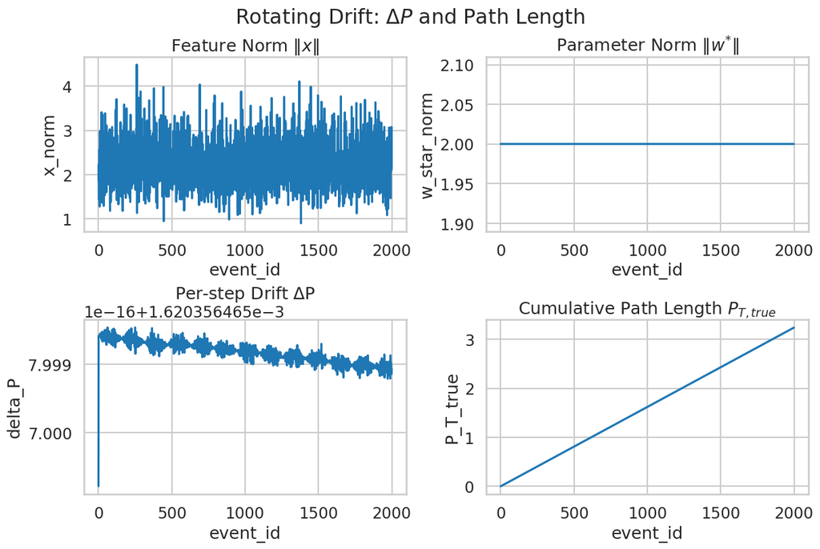

|  | event_id | x_norm | w_star_norm | delta_P | P_T_true | noise | lambda_est | y |
| --- | --- | --- | --- | --- | --- | --- | --- | --- |
| 0 | 0 | 1.879848 | 2.0 | 0.00162 | 0.001620 | -0.184174 | NaN | 0.224312 |
| 1 | 1 | 1.949441 | 2.0 | 0.00162 | 0.003241 | -0.023509 | 1.000022 | 1.941372 |
| 2 | 2 | 2.016157 | 2.0 | 0.00162 | 0.004861 | -0.126745 | 1.000020 | -0.657938 |
| 3 | 3 | 2.238905 | 2.0 | 0.00162 | 0.006481 | 0.027126 | 1.000016 | 0.611920 |
| 4 | 4 | 1.430259 | 2.0 | 0.00162 | 0.008102 | 0.015675 | 1.000011 | 1.347940 |

```python
# Demo 1: Rotating parameter path
N = 2000
stream = get_synthetic_linear_stream(
    dim=20,
    seed=7,
    noise_std=0.1,
    use_event_schema=True,
    cond_number=50.0,           # moderate anisotropy
    feature_scale=1.0,
    path_type="rotating",
    path_control=True,
    rotate_angle=0.01,          # radians per step
    w_scale=2.0,
    fix_w_norm=True,
    strong_convexity_estimation=True,
)

rot_events = take_events(stream, N)
rot_df = events_to_frame(rot_events)
fig, axes = plot_drift_summary(rot_df, title="Rotating Drift: $\Delta P$ and Path Length")
plt.show()

rot_df.head()
```

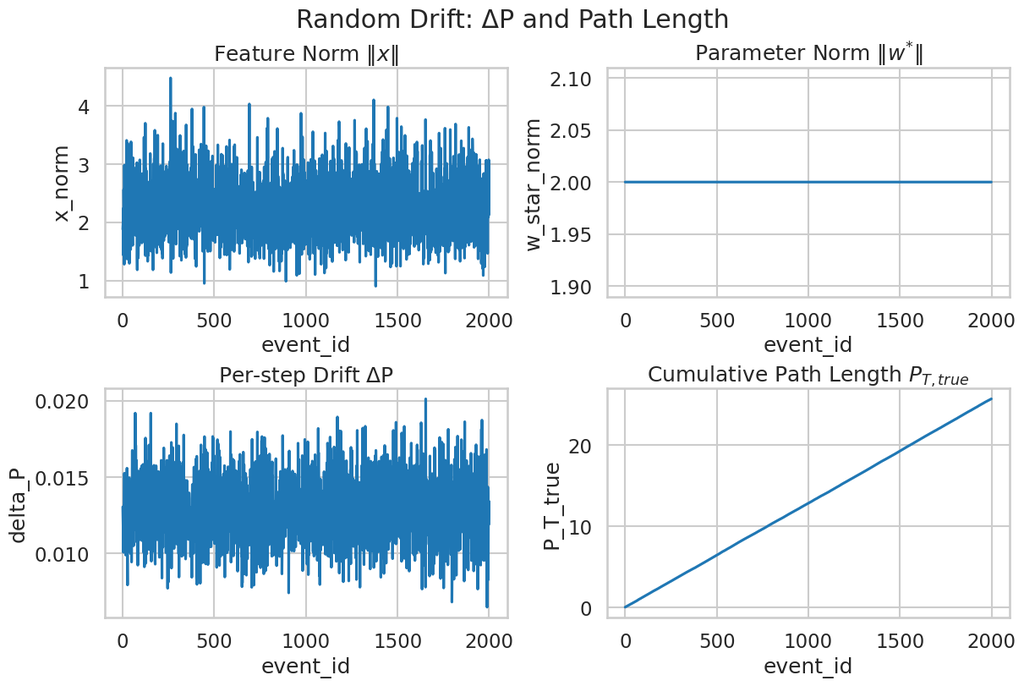

|  | event_id | x_norm | w_star_norm | delta_P | P_T_true | noise | lambda_est | y |
| --- | --- | --- | --- | --- | --- | --- | --- | --- |
| 0 | 0 | 1.879848 | 2.0 | 0.013039 | 0.013039 | -0.184174 | NaN | 0.226841 |
| 1 | 1 | 1.949441 | 2.0 | 0.012213 | 0.025252 | -0.023509 | 1.002426 | 1.945680 |
| 2 | 2 | 2.016157 | 2.0 | 0.011627 | 0.036880 | -0.126745 | 1.002401 | -0.674697 |
| 3 | 3 | 2.238905 | 2.0 | 0.010064 | 0.046944 | 0.027126 | 1.002348 | 0.613642 |
| 4 | 4 | 1.430259 | 2.0 | 0.010227 | 0.057170 | 0.015675 | 1.002297 | 1.353974 |

```python
# Demo 2: Stochastic linear drift in parameters
N = 2000
stream = get_synthetic_linear_stream(
    dim=20,
    seed=7,
    noise_std=0.1,
    use_event_schema=True,
    cond_number=50.0,
    feature_scale=1.0,
    path_type="drift",
    path_control=True,
    drift_rate=0.003,           # per-step drift scale
    w_scale=2.0,
    fix_w_norm=True,
    strong_convexity_estimation=True,
)

drift_events = take_events(stream, N)
drift_df = events_to_frame(drift_events)
fig, axes = plot_drift_summary(drift_df, title="Random Drift: ΔP and Path Length")
plt.show()

drift_df.head()
```

## Explore Further

- Increase `rotate_angle` (e.g., 0.03) to amplify per-step drift in the rotating path; `P_T_true` should grow near-linearly with a higher slope.
- Increase `drift_rate` (e.g., 0.01) to make `delta_P` noisier and `P_T_true` grow faster in the random drift case.
- Toggle `fix_w_norm` to see how changing ‖w*‖ interacts with targets and diagnostics; when `False`, expect `w_star_norm` to vary.
- Adjust `cond_number` to shape `x_norm` behavior via anisotropy; larger values concentrate variance along top directions.
- Set `feature_scale` > 1 to scale feature norms and widen the range of `y`.
- Disable `strong_convexity_estimation` to remove `lambda_est` and reduce overhead if not needed.

Tip: The iterator is infinite—use small `N` for quick experiments and scale up as needed.

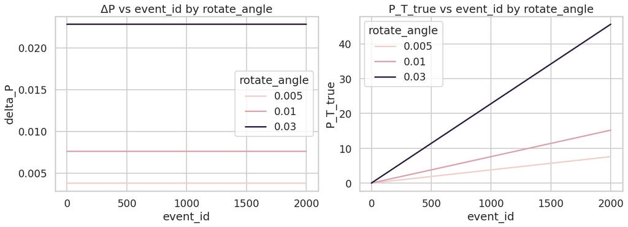

| rotate_angle | mean_delta_P |
| --- | --- |
| 0.005 | 0.003803 |
| 0.010 | 0.007606 |
| 0.030 | 0.022816 |

```python
# Explore: effect of rotate_angle on drift metrics
N = 2000
angles = [0.005, 0.01, 0.03]
results = []
for ang in angles:
    s = get_synthetic_linear_stream(
        dim=20, seed=11, noise_std=0.1, use_event_schema=True,
        cond_number=50.0, feature_scale=1.0,
        path_type="rotating", path_control=True,
        rotate_angle=ang, w_scale=2.0, fix_w_norm=True,
        strong_convexity_estimation=False,
    )
    ev = take_events(s, N)
    df = events_to_frame(ev)
    df["rotate_angle"] = ang
    results.append(df)
rot_angle_df = pd.concat(results, ignore_index=True)

fig, axes = plt.subplots(1, 2, figsize=(14, 5), constrained_layout=True)
sns.lineplot(data=rot_angle_df, x="event_id", y="delta_P", hue="rotate_angle", ax=axes[0])
axes[0].set_title("ΔP vs event_id by rotate_angle")
sns.lineplot(data=rot_angle_df, x="event_id", y="P_T_true", hue="rotate_angle", ax=axes[1])
axes[1].set_title("P_T_true vs event_id by rotate_angle")
plt.show()
rot_angle_df.groupby("rotate_angle")["delta_P"].mean().to_frame("mean_delta_P")
```

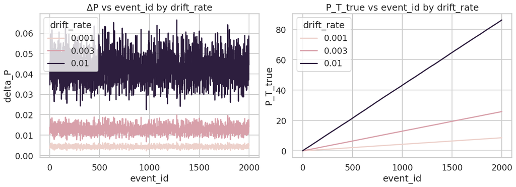

| drift_rate | mean_delta_P |
| --- | --- |
| 0.001 | 0.004313 |
| 0.003 | 0.012936 |
| 0.010 | 0.043105 |

```python
# Explore: effect of drift_rate on drift metrics
N = 2000
rates = [0.001, 0.003, 0.01]
results = []
for rate in rates:
    s = get_synthetic_linear_stream(
        dim=20, seed=13, noise_std=0.1, use_event_schema=True,
        cond_number=50.0, feature_scale=1.0,
        path_type="drift", path_control=True,
        drift_rate=rate, w_scale=2.0, fix_w_norm=True,
        strong_convexity_estimation=False,
    )
    ev = take_events(s, N)
    df = events_to_frame(ev)
    df["drift_rate"] = rate
    results.append(df)
drift_rate_df = pd.concat(results, ignore_index=True)

fig, axes = plt.subplots(1, 2, figsize=(14, 5), constrained_layout=True)
sns.lineplot(drift_rate_df, x="event_id", y="delta_P", hue="drift_rate", ax=axes[0])
axes[0].set_title("ΔP vs event_id by drift_rate")
sns.lineplot(drift_rate_df, x="event_id", y="P_T_true", hue="drift_rate", ax=axes[1])
axes[1].set_title("P_T_true vs event_id by drift_rate")
plt.show()
drift_rate_df.groupby("drift_rate")["delta_P"].mean().to_frame("mean_delta_P")
```

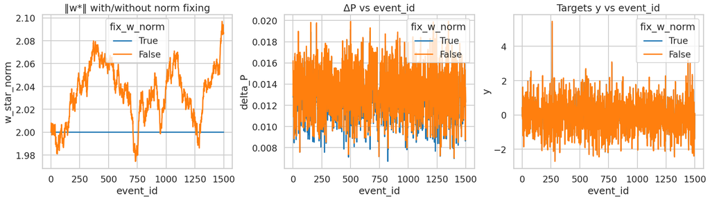

| fix_w_norm | mean | std |
| --- | --- | --- |
| False | 2.034112 | 2.455020e-02 |
| True | 2.000000 | 1.798110e-16 |

```python
# Explore: effect of fix_w_norm on parameter norm and targets
N = 1500
settings = [True, False]
res = []
for fix in settings:
    s = get_synthetic_linear_stream(
        dim=20, seed=17, noise_std=0.1, use_event_schema=True,
        cond_number=50.0, feature_scale=1.0,
        path_type="drift", path_control=True,
        drift_rate=0.003, w_scale=2.0, fix_w_norm=fix,
        strong_convexity_estimation=False,
    )
    ev = take_events(s, N)
    df = events_to_frame(ev)
    df["fix_w_norm"] = str(fix)
    res.append(df)
fix_df = pd.concat(res, ignore_index=True)

fig, axes = plt.subplots(1, 3, figsize=(18, 5), constrained_layout=True)
sns.lineplot(fix_df, x="event_id", y="w_star_norm", hue="fix_w_norm", ax=axes[0])
axes[0].set_title("‖w*‖ with/without norm fixing")
sns.lineplot(fix_df, x="event_id", y="delta_P", hue="fix_w_norm", ax=axes[1])
axes[1].set_title("ΔP vs event_id")
sns.lineplot(fix_df, x="event_id", y="y", hue="fix_w_norm", ax=axes[2])
axes[2].set_title("Targets y vs event_id")
plt.show()
fix_df.groupby("fix_w_norm")["w_star_norm"].agg(["mean","std"])
```

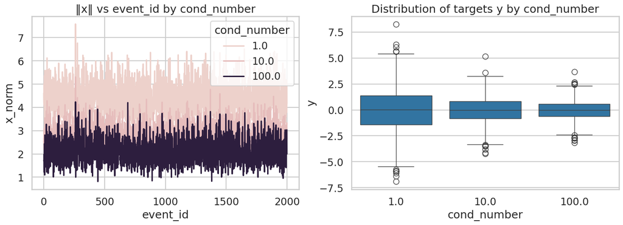

| cond_number | mean_x_norm |
| --- | --- |
| 1.0 | 4.440494 |
| 10.0 | 2.781608 |
| 100.0 | 2.085392 |

```python
# Explore: effect of cond_number (feature anisotropy) on x_norm and y variance
N = 2000
conds = [1.0, 10.0, 100.0]
rows = []
for c in conds:
    s = get_synthetic_linear_stream(
        dim=20, seed=23, noise_std=0.1, use_event_schema=True,
        cond_number=c, feature_scale=1.0,
        path_type="rotating", path_control=True,
        rotate_angle=0.01, w_scale=2.0, fix_w_norm=True,
        strong_convexity_estimation=False,
    )
    ev = take_events(s, N)
    df = events_to_frame(ev)
    df["cond_number"] = c
    rows.append(df)
cond_df = pd.concat(rows, ignore_index=True)

fig, axes = plt.subplots(1, 2, figsize=(14, 5), constrained_layout=True)
sns.lineplot(cond_df, x="event_id", y="x_norm", hue="cond_number", ax=axes[0])
axes[0].set_title("‖x‖ vs event_id by cond_number")
sns.boxplot(cond_df, x="cond_number", y="y", ax=axes[1])
axes[1].set_title("Distribution of targets y by cond_number")
plt.show()
cond_df.groupby("cond_number")["x_norm"].mean().to_frame("mean_x_norm")
```

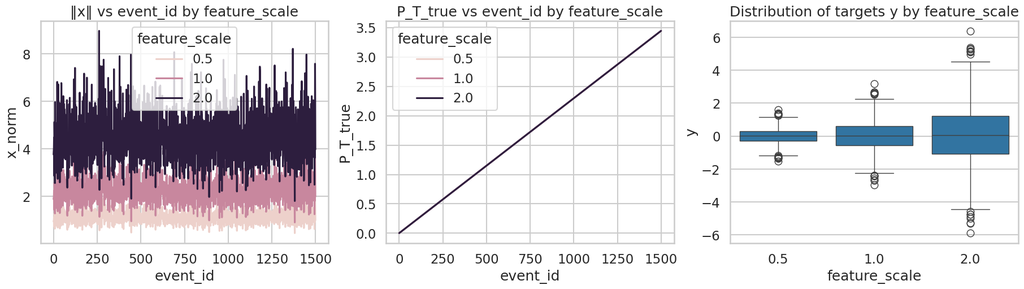

| feature_scale | mean_x_norm |
| --- | --- |
| 0.5 | 1.121626 |
| 1.0 | 2.243251 |
| 2.0 | 4.486503 |

```python
# Explore: effect of feature_scale on norms and targets
N = 1500
scales = [0.5, 1.0, 2.0]
recs = []
for s in scales:
    stream = get_synthetic_linear_stream(
        dim=20, seed=29, noise_std=0.1, use_event_schema=True,
        cond_number=50.0, feature_scale=s,
        path_type="rotating", path_control=True,
        rotate_angle=0.01, w_scale=2.0, fix_w_norm=True,
        strong_convexity_estimation=False,
    )
    ev = take_events(stream, N)
    df = events_to_frame(ev)
    df["feature_scale"] = s
    recs.append(df)
scale_df = pd.concat(recs, ignore_index=True)

fig, axes = plt.subplots(1, 3, figsize=(18, 5), constrained_layout=True)
sns.lineplot(scale_df, x="event_id", y="x_norm", hue="feature_scale", ax=axes[0])
axes[0].set_title("‖x‖ vs event_id by feature_scale")
sns.lineplot(scale_df, x="event_id", y="P_T_true", hue="feature_scale", ax=axes[1])
axes[1].set_title("P_T_true vs event_id by feature_scale")
sns.boxplot(scale_df, x="feature_scale", y="y", ax=axes[2])
axes[2].set_title("Distribution of targets y by feature_scale")
plt.show()
scale_df.groupby("feature_scale")["x_norm"].mean().to_frame("mean_x_norm")
```

# Comprehensive Theory-First Configurations

This section demonstrates comprehensive use of the theory-first approach with various theoretical drift configurations.

```python
# Comprehensive demonstration of theoretical drift configurations

configs = {
    'Low Complexity': {
        'target_G': 1.0, 'target_D': 2.0, 'target_lambda': 0.1,
        'target_PT': 10.0, 'target_ST': 500.0, 'target_c': 0.1, 'target_C': 10.0
    },
    'High Complexity': {
        'target_G': 5.0, 'target_D': 4.0, 'target_lambda': 0.01,
        'target_PT': 100.0, 'target_ST': 5000.0, 'target_c': 0.001, 'target_C': 1000.0
    },
    'Stable Drift': {
        'target_G': 2.0, 'target_D': 3.0, 'target_lambda': 0.05,
        'target_PT': 25.0, 'target_ST': 1000.0, 'target_c': 0.01, 'target_C': 100.0,
        'path_style': 'rotating'
    },
    'Chaotic Drift': {
        'target_G': 2.0, 'target_D': 3.0, 'target_lambda': 0.05,
        'target_PT': 25.0, 'target_ST': 1000.0, 'target_c': 0.01, 'target_C': 100.0,
        'path_style': 'brownian'
    }
}

print('Theory-first configurations demonstrate precise control over:')
for name, config in configs.items():
    print(f'  {name}: P_T={config["target_PT"]}, G={config["target_G"]}, λ={config["target_lambda"]}')

# Example: create a theory stream with controlled drift
example_stream = get_theory_stream(
    dim=5, T=100, **configs['Stable Drift'],
    accountant='zcdp', rho_total=1.0, seed=42
)

# Show first few events
for i in range(3):
    event = next(example_stream)
    print(f'Event {i}: P_T={event["metrics"]["P_T_true"]:.3f}, G={event["metrics"]["g_norm"]:.3f}')
```

[output not shown]

## Conclusion: Theory-First Approach Benefits

The theory-first `get_theory_stream()` approach provides:

1. **Direct Theoretical Control**: Specify gradient bounds, path length, strong convexity directly
2. **Integrated Privacy**: Built-in zCDP and (ε,δ)-DP accounting
3. **Rich Diagnostics**: Real-time constraint adherence monitoring
4. **Flexible Drift Patterns**: Multiple path styles (rotating, brownian, piecewise-constant)
5. **Experimental Reproducibility**: Theory-driven parameterization

**Use `get_theory_stream()` for new experiments** to leverage theoretical drift configurations.